# Hate in Context

Week 6: Political Elites and Hate Crime · LENS preview

Violeta Haas

Department of Political Science

School of Social Sciences and Philosophy

Trinity College Dublin

# Updates

### Strike

- Industrial action ongoing, but Wednesday’s class takes place
- Fairness cut stays: Dancygier (2023) no longer required
- If time allows, I’ll show some of the Dancygier findings

### Position paper

- Apologies for the delay in returning these
- First batch has been released
- Second batch coming today
- Next batch by Wednesday

# This Week

1. Catch-up: Riaz, Bischof & Wagner (2024)
2. Theoretical backdrop
3. Zonszein & Grossman (2025)
4. Romarri (2020)
5. Mid-course synthesis (group task)
6. Outlook

# Riaz, Bischof & Wagner (2024)

## Overview

- **Research question:** Do local immigrant-attributed crimes raise hate crimes against refugees?
- **Y:** daily probability/count of hate crimes against refugees
- **X:** immigrant-attributed crime event
- **Theory:** vicarious retribution, i.e., natives retaliate against uninvolved out-group members after a triggering crime
- **Design:** regression discontinuity in time (RDiT) around local crime events (Germany, 2015–2019)

**Wait… RDiT? That sounds familiar!**

## Regression Discontinuity in Time (RDiT) design

**Idea:** a sudden local shock is a cutoff in time. Compare hate crimes from the before period vs the after period.

Comparison around local crime events

Same county, days close to the event

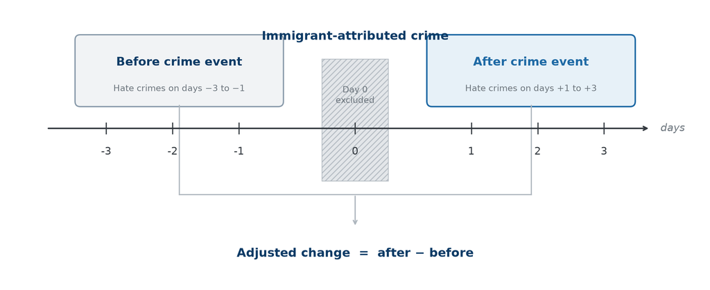

## Scope conditions

[discussed in class]

How do natives (including potential hate crime perpetrators) hear about immigrant-attributed crime in their locality?

[discussed in class]

[discussed in class]

## Findings: daily hate-crime rate around events

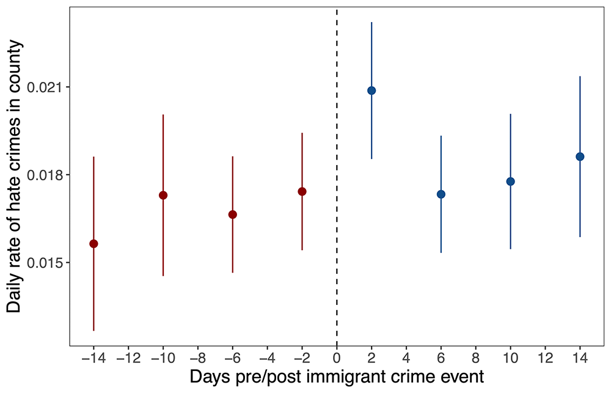

**Hate crimes surge** locally right after immigrant-attributed crimes but spike **fades within ~4 days**, consistent with an **emotional trigger (affect)**.

## Findings: where the backlash is stronger

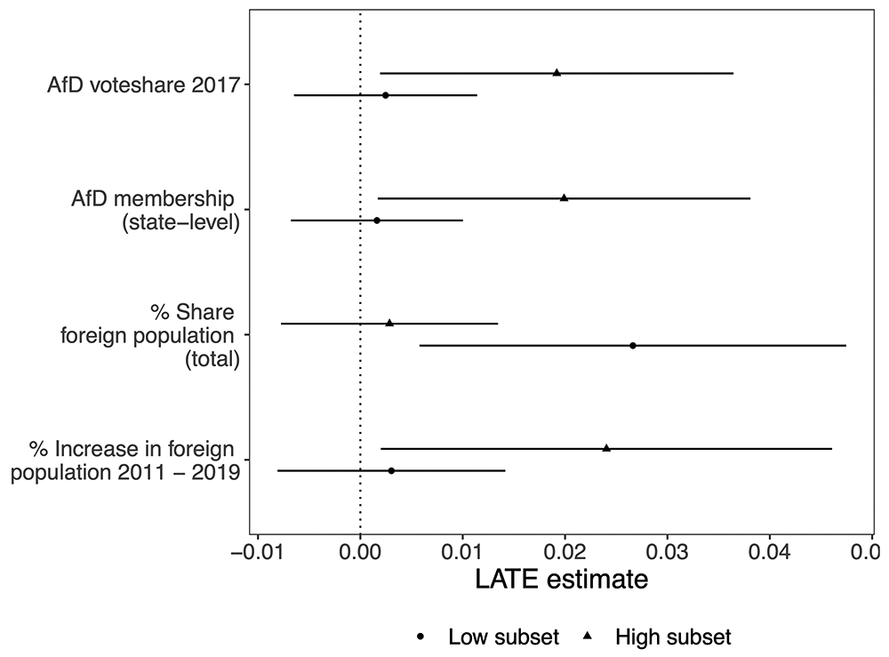

Backlash is stronger where **far-right mobilization potential** is high and where the **foreign population has recently increased**, not simply where many foreigners already live.

Anything else that didn’t convince you?

# Theoretical backdrop

## Discussion: social identity theory

**In groups of 3-4 (≈5 min):**

1. What does social identity theory say?
2. Social identity theory has three components: categorization, identification, and comparison. What does each mean?
3. When people belong to a devalued/low-status group, what coping strategies can they use?

## Social identity theory

[discussed in class]

## Coping with low group status

[discussed in class]

## Group discussion

**In groups of 3-4:**

1. What is the difference between descriptive and substantive representation?
2. What are ways to increase descriptive and substantive representation?
3. Can a politician descriptively represent a group without substantively representing it (or vice versa)? Give an example.

## Descriptive vs substantive representation

[discussed in class]

## Example

[discussed in class]

# Zonszein & Grossman (2025)

## Overview

How do natives react when immigrant-origin minorities win political office?

**What informational cues are natives supposed to receive when a minority candidate is elected?**

[discussed in class]

**Which actors’ reactions are Zonszein & Grossman (2024) looking at and which outcome corresponds to which actor?**

[discussed in class]

## Design: another regression discontinuity

**Setting:** UK general elections, 2010–2019 (England & Wales)

**Idea:** near a razor-thin election, who wins is *as-good-as-random*. Compare places just above vs just below the win cutoff.

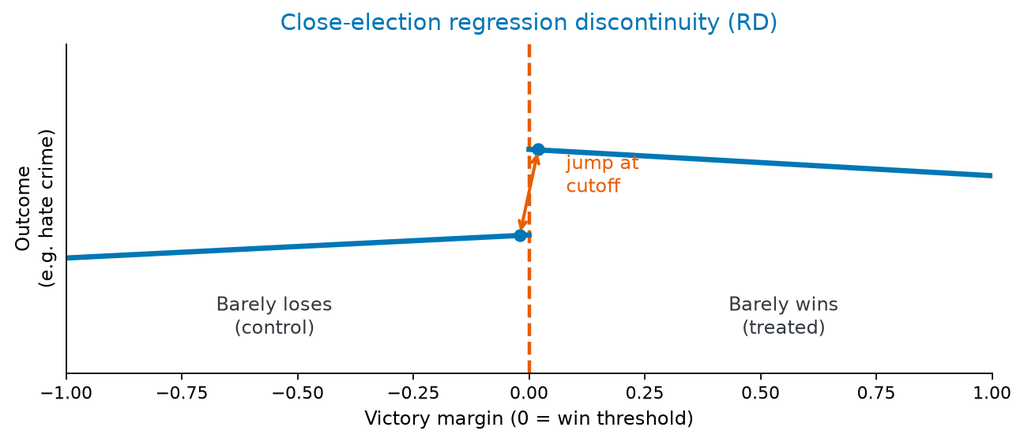

What we estimate is a LATE (*local average treatment effect*): the average causal effect at the cutoff, i.e., for places with close races ≠ effect for all elections, i.e., landslide elections.

## Findings on hate crimes (perpetrators)

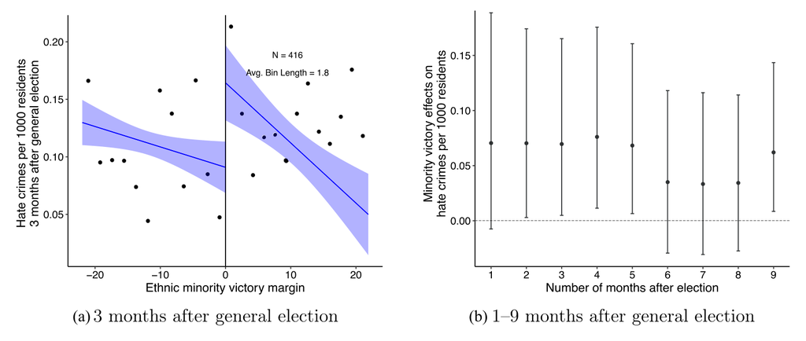

≈ +67% hate crimes (3 months post-election) relative to barely-losing minority constituencies.

## Findings on attitudes (mass public)

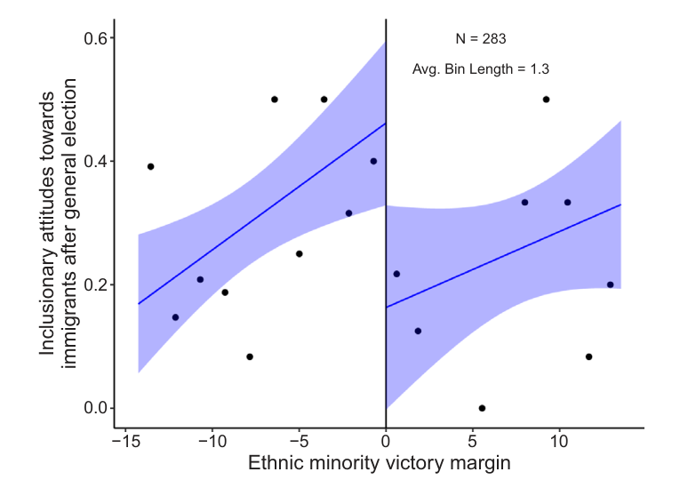

Why would the media report negatively about minorities?

## Two reasons

[discussed in class]

## Findings on media coverage (media/elites)

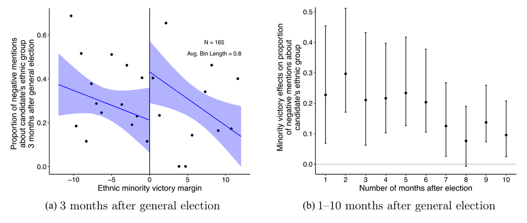

≈ +110% more negative coverage of the relevant immigrant group

Concentrated in right-wing and smaller-circulation papers

## Neighbor discussion (≈3–4 min)

**Turn to a neighbor:**

1. Does this mean descriptive representation produces backlash?
2. Why is the alternative explanation of reporting increases particularly important to rule out here?
3. Do natives respond to all winning minority candidates the same way?

[discussed in class]

[discussed in class]

[discussed in class]

## Implication: the paradox of political integration

Like Dancygier et al. (2022), who show that social integration into dating/marriage markets triggered hostility, Zonszein & Grossman (2025) show that integrating into political institutions can produce backlash.

**Integration success ≠ automatically less hate crime. Sometimes the success *is* the trigger.**

## But: only first-time minority wins

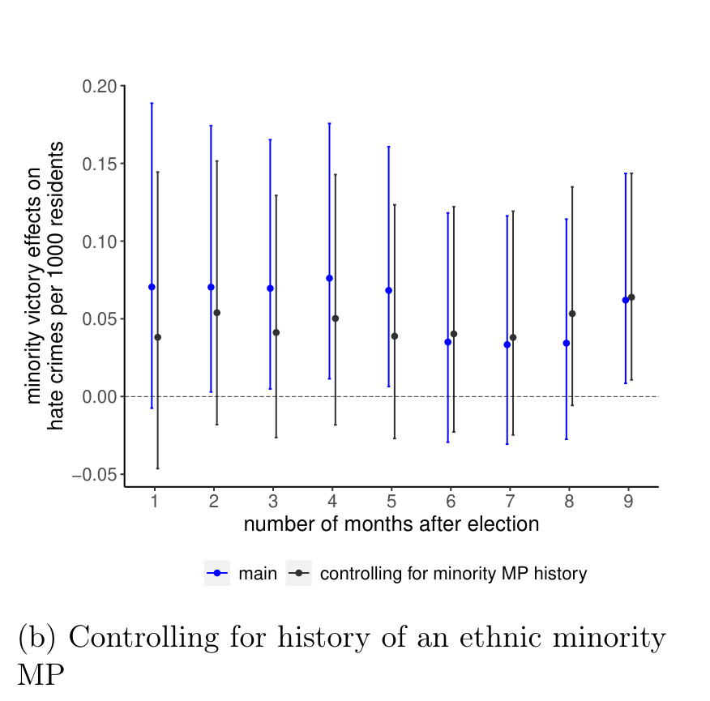

Effect concentrated in constituencies electing a minority MP for the **first time**

Critique?

# Romarri (2020)

## Overview

- **Research question:** Do far-right mayors raise the probability of hate crimes against immigrants?
- **Setting:** Italian municipal mayoral elections, 2008–2018
- **Y:** yearly indicator that at least one hate crime is recorded (Lunaria)
- **X/treatment:** far-right mayor in office
- **Design:** close-election RD (far-right margin of victory)

## Main RD result

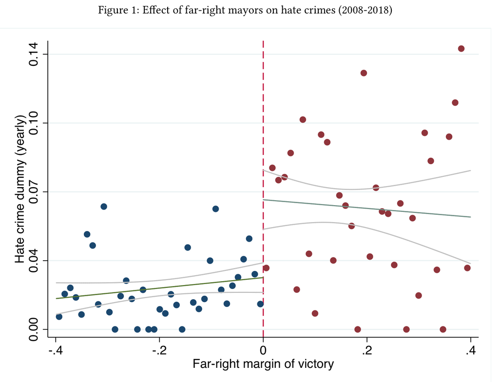

Also for **severe acts** (assaults / damage); strongest **early in the mandate** and for mayors who are **not re-electable**

## Mechanisms

### 1. Erosion of social norms

Far-right wins can make people feel less alone in their prejudice → more willing to act (Bursztyn et al., 2020).

Results driven by first-time far-right mayors + spillovers into neighbouring municipalities.

### 2. Internet/broadband

Effect concentrated where broadband exposure is high, and fades where coverage is low (links to Week 4).

But not necessarily via easier group coordination. No differential effect on group-committed hate crimes by internet coverage.

## Two takeaways

### Zonszein & Grossman

A minority win can make an unsatisfactory status comparison salient → backlash to restore positive distinctiveness.

### Romarri

A far-right win can signal that the in-group’s exclusionary stance is more widely shared/more legitimate → less restraint on acting against out-groups.

**Who wins office can shape identity comparisons and social norms, activating hostile attitudes and behavior.**

Causes Weeks 2–6 Demographic change  
Economic conditions  
(Social) media  
Threatening events  
Political elites

Consequences Week 8 Community impacts

Responses Weeks 9–10 Contact  
Persuasion

Guest lecture Week 11 Inclusionary policy  
Exclusionary policy

Your choice Week 12 Propose topic by  
Fri 23 Oct, 11:59 pm

## Group task (20–25 min)

**POU44653: Determinants of Hate Crime (Weeks 1–6)** — fill your group’s shared Word doc (link on Blackboard).

If time allows: short group spotlights — each group presents one part of what you put together.

### Groups

A · Weeks 1–2  
definition + demography

B · Weeks 3–4  
economy + media

C · Weeks 5–6  
threatening events + pol. elites

### What to cover

1. Core concepts, theories and definitions
2. Theoretical argument and mechanism
3. Actors and outcomes
4. Research designs
5. Data sources
6. Policy implications
7. Open questions

**You’ll be able to draw on this document when developing your Research Proposal.**

# Outlook

## Next up

Reading Week (26 Oct–1 Nov): no class.

After Reading Week:

- Week 8 (Mon 2/Wed 4 Nov): community impacts of hate crime
- Research-proposal topic meetings (Weeks 8–9): book a 15-minute slot when the booking link goes up